# Time Series HW2

Curtis Zhuang

2021/4/12

#### 1. Load the visitors.rda dataset, make a time plot of your data and describe the main features of the series.

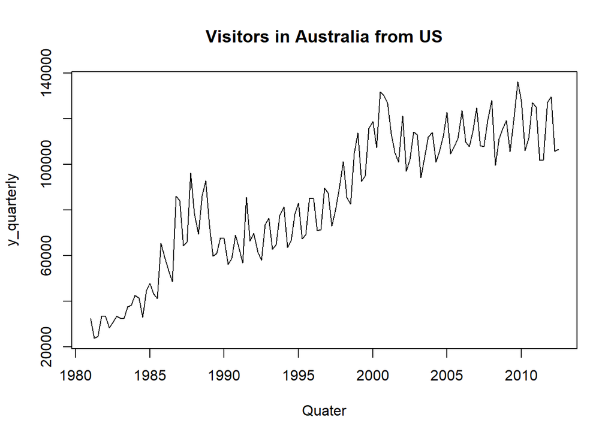

```r
load('visitors.rda')

y_quarterly <-  ts(visitors$Arrivals, start=c(1981, 1), frequency=4)

plot(y_quarterly, main = 'Visitors in Australia from US', xlab = 'Quater')
```

**Based on the graph, we see that the trend of visitors is positive overall and there is seasonality involved which happens yearly. The peak is during winter quarters. The level of the data also increases over time.**

#### 2. What is the appropriate Holt-Winters method for this data set (multiplicative / additive)? why?

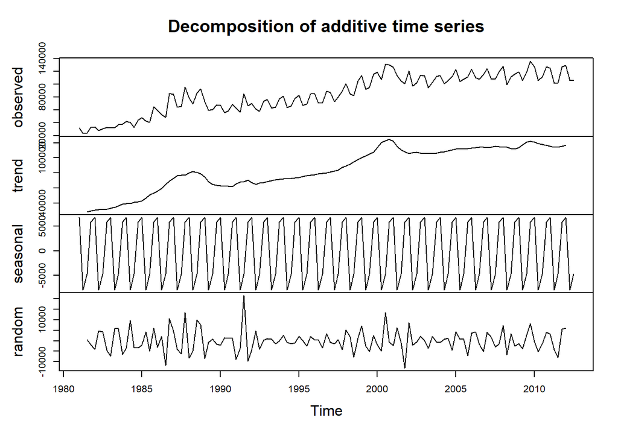

```r
# Additive
fit_add <- decompose(y_quarterly, type="additive")

plot(fit_add)
```

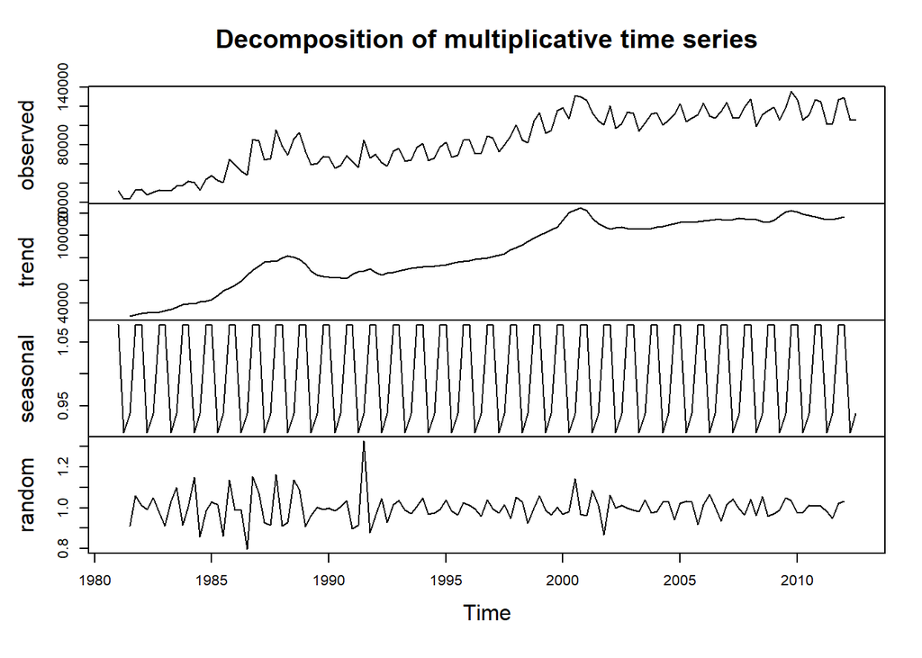

```r
# Multiplicative
fit_mult <- decompose(y_quarterly, type="multiplicative")

plot(fit_mult)
```

**Based on the two plots, I think a multiplicative time series fits better. From graph of Q1, we see that for each rise and fall cycle, the distance between peak and bottom becomes larger and then fluctutates, and thus additive will not be ideal in this case.**

#### 3.Use the hw() function to forecast the next 16 quarters using Holt-Winters’ methods.

• Linear trend with additive seasonality

```r
fit_hw_add_1 <- hw(y_quarterly, h=16, seasonal="add",damped=FALSE)
summary(fit_hw_add_1)
```

• Linear trend with multiplicative seasonality

```r
fit_hw_mul_1 <- hw(y_quarterly, h=16, seasonal="mult",damped=FALSE)
summary(fit_hw_mul_1)
```

• Linear trend with additive seasonality and damping

```r
fit_hw_add_2 <- hw(y_quarterly, h=16, seasonal="add",damped=TRUE)
summary(fit_hw_add_2)
```

• Linear trend with multiplicative seasonality and damping

```r
fit_hw_mul_2 <- hw(y_quarterly, h=16, seasonal="mult",damped=TRUE)
summary(fit_hw_mul_2)
```

• Seasonal Naive

```r
fit_sn <- snaive(y_quarterly, h = 16)
summary(fit_sn)
```

#### 4.Use the accuracy() function to compare the Root-Mean-Square-Error (RMSE) values of the forecasts from the various methods. Which do you prefer and why?

```r
rmse_hw_add_no_damp <- accuracy(fit_hw_add_1)[2]
rmse_hw_mul_no_damp <- accuracy(fit_hw_mul_1)[2]
rmse_hw_add_damp <- accuracy(fit_hw_add_2)[2]
rmse_hw_mul_damp <- accuracy(fit_hw_mul_2)[2]
rmse_sn <- accuracy(fit_sn)[2]

paste(rmse_hw_add_no_damp, rmse_hw_mul_no_damp, rmse_hw_add_damp, rmse_hw_mul_damp, rmse_sn, sep = ", ")
```

```
## [1] "7542.65568343343, 7550.9560612106, 7552.06372903441, 7460.00153236291, 10298.9849101191"
```

**I prefer using Holt-Winters’ method with linear trend, multiplicative seasonality and with damping, as it provides me with the smallest RMSE = 7460.**

#### 5.Use the checkresiduals() function to check that the residuals from the best model look like white noise and provide a summary of the model’s smoothing parameters using the summary() function.

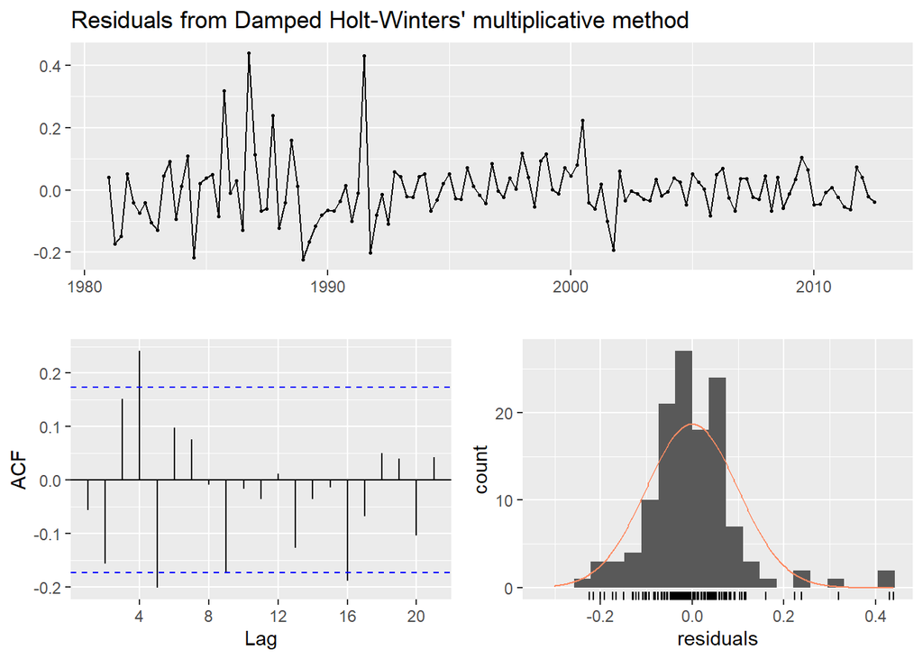

```
##
##  Ljung-Box test
##
## data:  Residuals from Damped Holt-Winters' multiplicative method
## Q* = 26.266, df = 3, p-value = 8.388e-06
##
## Model df: 9.   Total lags used: 12
```

```r
checkresiduals(fit_hw_mul_2)
```

```r
summary(fit_hw_mul_2)
```

```
##
## Forecast method: Damped Holt-Winters' multiplicative method
##
## Model Information:
## Damped Holt-Winters' multiplicative method
##
## Call:
##  hw(y = y_quarterly, h = 16, seasonal = "mult", damped = TRUE)
##
##   Smoothing parameters:
##     alpha = 0.52
##     beta  = 0.0027
##     gamma = 1e-04
##     phi   = 0.98
##
##   Initial states:
##     l = 26914.2591
##     b = 2002.8599
##     s = 1.0638 0.9467 0.9133 1.0762
##
##   sigma:  0.1034
##
##      AIC     AICc      BIC
## 2913.642 2915.538 2942.084
##
## Error measures:
##                     ME     RMSE     MAE        MPE     MAPE      MASE
## Training set -1.834419 7460.002 5363.22 -0.9701216 6.852661 0.7266756
##                      ACF1
## Training set -0.001971966
##
## Forecasts:
##         Point Forecast     Lo 80    Hi 80    Lo 95    Hi 95
## 2012 Q4       122225.2 106033.32 138417.1 97461.86 146988.5
## 2013 Q1       123798.8 105276.90 142320.8 95471.97 152125.7
## 2013 Q2       105187.4  87816.96 122557.8 78621.62 131753.1
## 2013 Q3       109171.5  89578.75 128764.3 79206.97 139136.1
## 2013 Q4       122829.1  99138.55 146519.6 86597.54 159060.7
## 2014 Q1       124397.5  98830.37 149964.7 85295.93 163499.2
## 2014 Q2       105685.3  82691.88 128678.6 70519.92 140850.6
## 2014 Q3       109677.3  84552.31 134802.3 71251.94 148102.7
## 2014 Q4       123386.1  93754.23 153018.0 78068.05 168704.2
## 2015 Q1       124949.8  93607.44 156292.1 77015.81 172883.7
## 2015 Q2       106144.5  78421.35 133867.7 63745.60 148543.4
## 2015 Q3       110143.9  80270.02 140017.7 64455.77 155832.0
## 2015 Q4       123899.9  89083.75 158716.1 70653.18 177146.7
## 2016 Q1       125459.1  89009.06 161909.2 69713.57 181204.7
## 2016 Q2       106568.1  74614.21 138522.0 57698.83 155437.4
## 2016 Q3       110574.2  76411.57 144736.8 58326.96 162821.4
```

**From our previous finding in Q2, I think the best model is multiplicative seasonality with damping. The smoothing parameters for the best model are: $\alpha = 0.52, \beta = 0.0027, \gamma = 1e-04, \phi = 0.98.$**

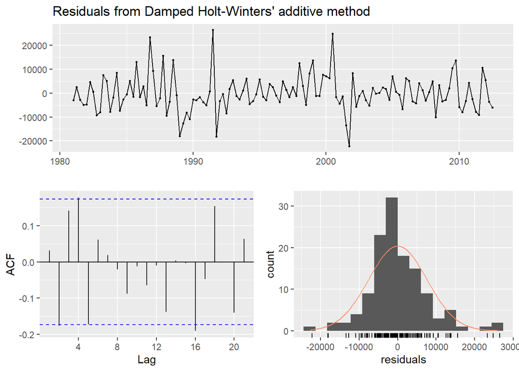

```
##
##  Ljung-Box test
##
## data:  Residuals from Damped Holt-Winters' additive method
## Q* = 17.44, df = 3, p-value = 0.0005736
##
## Model df: 9.   Total lags used: 12
```

```r
checkresiduals(fit_hw_add_2)
```

```r
summary(fit_hw_add_2)
```

```
##
## Forecast method: Damped Holt-Winters' additive method
##
## Model Information:
## Damped Holt-Winters' additive method
##
## Call:
##  hw(y = y_quarterly, h = 16, seasonal = "add", damped = TRUE)
##
##   Smoothing parameters:
##     alpha = 0.4702
##     beta  = 1e-04
##     gamma = 0.0761
##     phi   = 0.98
##
##   Initial states:
##     l = 26752.4056
##     b = 1912.2775
##     s = 5901.9 -4718.818 -7842.813 6659.731
##
##   sigma:  7834.775
##
##      AIC     AICc      BIC
## 2903.324 2905.221 2931.766
##
## Error measures:
##                    ME     RMSE      MAE        MPE     MAPE     MASE       ACF1
## Training set 18.41066 7552.064 5551.979 -0.8327106 7.471211 0.752251 0.03207652
##
## Forecasts:
##         Point Forecast     Lo 80    Hi 80     Lo 95    Hi 95
## 2012 Q4       121033.7 110993.04 131074.4 105677.84 136389.6
## 2013 Q1       123116.0 112020.39 134211.7 106146.71 140085.4
## 2013 Q2       105058.3  92999.21 117117.4  86615.52 123501.0
## 2013 Q3       109824.8  96873.38 122776.1  90017.34 129632.2
## 2013 Q4       121581.7 107515.11 135648.4 100068.68 143094.8
## 2014 Q1       123653.1 108813.84 138492.4 100958.40 146347.8
## 2014 Q2       105584.6  90010.70 121158.5  81766.38 129402.8
## 2014 Q3       110340.5  94064.89 126616.2  85449.08 135232.0
## 2014 Q4       122087.2 104909.68 139264.8  95816.44 148358.0
## 2015 Q1       124148.5 106331.79 141965.2  96900.21 151396.8
## 2015 Q2       106070.1  87636.16 124504.0  77877.84 134262.3
## 2015 Q3       110816.3  91784.99 129847.6  81710.42 139922.2
## 2015 Q4       122553.5 102744.43 142362.5  92258.17 152848.7
## 2016 Q1       124605.4 104238.90 144971.9  93457.53 155753.3
## 2016 Q2       106517.8  85608.56 127427.1  74539.86 138495.8
## 2016 Q3       111255.1  89816.63 132693.6  78467.78 144042.5
```

**However, if we only look at the ACF alone considering white noise, the best model is the additive seasonality with damping, and the smoothing parameters for that are: $\alpha = 0.4702, \beta = 1e-04, \gamma = 0.0761, \phi = 0.98$**